# Allometry

Antigoni Kaliontzopoulou, Dean Adams & Michael Collyer

28 May, 2026

## **Content Description**

Allometry, the covariation of shape with size, is a critically-important pattern to evaluate in morphometric analyses. Here we show several analyses available in `geomorph` for investigating shape-size relationships. For the case of allometry, many options are concatenated in the `plotAllometry` function in `geomorph`. However, for those based on linear models, one can arrive at similar analytics and plots using the `procD.lm` approach.

## **1: Simple allometry**

Here we provide the case of a simple allometric pattern in a single group. We have seen these analyses before:

```r
library(geomorph)
data(plethodon)
Y.gpa <- gpagen(plethodon$land, print.progress = FALSE)    #GPA-alignment
gdf <- geomorph.data.frame(Y.gpa, site = plethodon$site,
species = plethodon$species)
fit <- procD.lm(coords ~ log(Csize), data=gdf, iter=999, print.progress = FALSE)
anova(fit)
```

```
##
## Analysis of Variance, using Residual Randomization
## Permutation procedure: Randomization of null model residuals
## Number of permutations: 1000
## Estimation method: Ordinary Least Squares
## Sums of Squares and Cross-products: Type I
## Effect sizes (Z) based on F distributions
##
##            Df       SS        MS     Rsq      F      Z Pr(>F)
## log(Csize)  1 0.008894 0.0088940 0.04516 1.7973 1.2055  0.122
## Residuals  38 0.188046 0.0049486 0.95484
## Total      39 0.196940
##
## Call: procD.lm(f1 = coords ~ log(Csize), iter = 999, data = gdf, print.progress = FALSE)
```

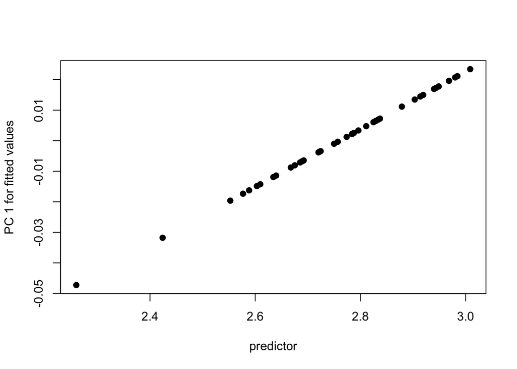

```r
# Predline
plotAllometry(fit, size = gdf$Csize, logsz = TRUE, method = "PredLine", pch = 19)
```

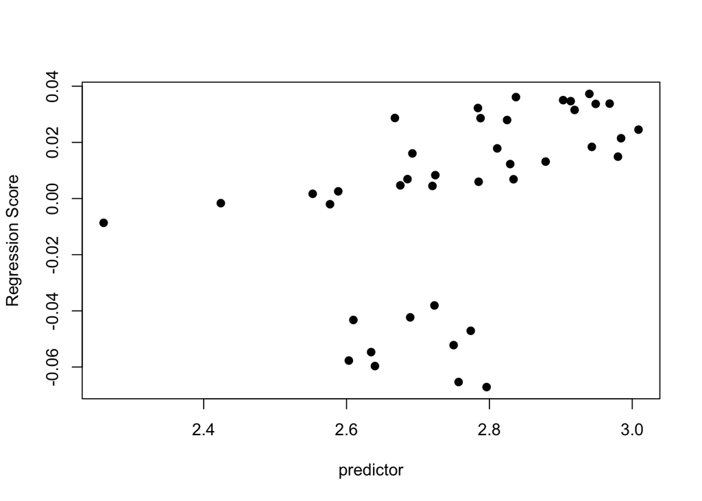

```r
# same as
logSize <- log(gdf$Csize)
plot(fit, type = "regression", reg.type = "PredLine", predictor = logSize, pch = 19)

# RegScore
plotAllometry(fit, size = gdf$Csize, logsz = TRUE, method = "RegScore", pch = 19)
```

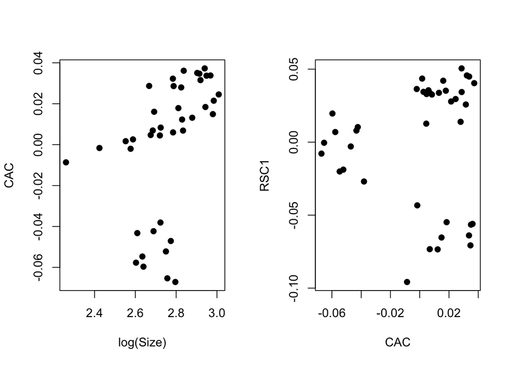

```r
# same as
plot(fit, type = "regression", reg.type = "RegScore", predictor = logSize, pch = 19)

# CAC
plotAllometry(fit, size = gdf$Csize, logsz = TRUE, method = "CAC", pch = 19)
```

## **2: Group Allometries**

Next, we add some biological realism, and consider the case of allometry patterns in multiple groups. This, of course, represents an ANCOVA design: analysis of covariance. It requires a more complex linear model, and affords additional possibilities in terms of analytical approaches, and visualizations.

#### Note! Before ever launching into an investigation of allometric differences, it is wise to ask if groups have a common allometry or unique allometrices.

```r
fit.unique <- procD.lm(coords ~ Csize * species * site, data=gdf, iter=999, print.progress = FALSE)
fit.common <- procD.lm(coords ~ Csize + species * site, data=gdf, iter=999, print.progress = FALSE)
anova(fit.common, fit.unique, print.progress = FALSE)
```

```
##
## Analysis of Variance, using Residual Randomization
## Permutation procedure: Randomization of null model residuals
## Number of permutations: 1000
## Estimation method: Ordinary Least Squares
## Effect sizes (Z) based on F distributions
##
##                                        ResDf Df      RSS        SS        MS
## coords ~ Csize + species * site (Null)    35  1 0.068758
## coords ~ Csize * species * site           32  3 0.061998 0.0067603 0.0022534
## Total                                     39    0.196940
##                                             Rsq      F       Z    P Pr(>F)
## coords ~ Csize + species * site (Null) 0.000000
## coords ~ Csize * species * site        0.034327 1.1631 0.72441 0.23
## Total
```

## **2a: Pairwise Comparisons**

Based on the outcome of a homogeneity of slopes test, one may wish to perform different types of pairwise comparisons. These come in the form of: 1) comparisons of adjusted least-squares means (common slopes), 2) comparisons of slope angles (unique slopes), 3) comparisons of regression lengths (unique slopes), and 4) comparisons of group disparity. For the present example, #2 and #3 are most appropriate to investigate.

```r
anova(fit.unique)
```

```
##
## Analysis of Variance, using Residual Randomization
## Permutation procedure: Randomization of null model residuals
## Number of permutations: 1000
## Estimation method: Ordinary Least Squares
## Sums of Squares and Cross-products: Type I
## Effect sizes (Z) based on F distributions
##
##                    Df       SS       MS     Rsq       F      Z Pr(>F)
## Csize               1 0.010409 0.010409 0.05286  5.3727 2.9010  0.001 ***
## species             1 0.025661 0.025661 0.13030 13.2451 4.0885  0.001 ***
## site                1 0.063018 0.063018 0.31999 32.5264 5.4000  0.001 ***
## Csize:species       1 0.005065 0.005065 0.02572  2.6143 2.0487  0.021 *
## Csize:site          1 0.003539 0.003539 0.01797  1.8265 1.5177  0.065 .
## species:site        1 0.025389 0.025389 0.12892 13.1046 5.0356  0.001 ***
## Csize:species:site  1 0.001860 0.001860 0.00945  0.9602 0.0771  0.483
## Residuals          32 0.061998 0.001937 0.31481
## Total              39 0.196940
## ---
## Signif. codes:  0 '***' 0.001 '**' 0.01 '*' 0.05 '.' 0.1 ' ' 1
##
## Call: procD.lm(f1 = coords ~ Csize * species * site, iter = 999, data = gdf,
##     print.progress = FALSE)
```

```r
slope.pw <- pairwise(fit.unique, fit.null = fit.common,
                     groups = interaction(gdf$species, gdf$site),
                     covariate = gdf$Csize, print.progress = FALSE)
summary(slope.pw, test.type = "VC", angle.type = "deg") # angular differences
```

```
##
## Pairwise comparisons
##
## Groups: Jord.Allo Teyah.Allo Jord.Symp Teyah.Symp
##
## RRPP: 1000 permutations
##
## Slopes (vectors of variate change per one unit of covariate
##         change, by group):
## Vectors hidden (use show.vectors = TRUE to view)
##
## Pairwise statistics based on slopes vector correlations (r)
##           and angles, acos(r)
## The null hypothesis is that r = 1 (parallel vectors).
## This null hypothesis is better treated as the angle
##           between vectors = 0
##                                  r     angle UCL (95%)         Z Pr > angle
## Jord.Allo:Teyah.Allo  -0.006485958  90.37162  93.22208 1.4105011      0.072
## Jord.Allo:Jord.Symp    0.004216474  89.75841 104.94415 0.7665484      0.216
## Jord.Allo:Teyah.Symp   0.166188860  80.43370  85.67644 1.3058699      0.103
## Teyah.Allo:Jord.Symp  -0.296458259 107.24500 106.23172 1.7204646      0.041
## Teyah.Allo:Teyah.Symp  0.364741758  68.60831  90.43985 0.1827730      0.409
## Jord.Symp:Teyah.Symp  -0.346679895 110.28438 101.35380 2.2537961      0.010
```

```r
summary(slope.pw, test.type = "dist", angle.type = "deg") # amount of shape change differences
```

```
##
## Pairwise comparisons
##
## Groups: Jord.Allo Teyah.Allo Jord.Symp Teyah.Symp
##
## RRPP: 1000 permutations
##
## Slopes (vectors of variate change per one unit of covariate
##         change, by group):
## Vectors hidden (use show.vectors = TRUE to view)
##
## Pairwise distances between slope vector
##             (end-points), plus statistics
##                                 d   UCL (95%)         Z Pr > d
## Jord.Allo:Teyah.Allo  0.010587756 0.011530847 1.1229690  0.126
## Jord.Allo:Jord.Symp   0.014502604 0.018612567 0.2700248  0.385
## Jord.Allo:Teyah.Symp  0.007914191 0.009118903 0.9272206  0.181
## Teyah.Allo:Jord.Symp  0.017498387 0.019634012 1.0174507  0.146
## Teyah.Allo:Teyah.Symp 0.008315986 0.010649304 0.4119917  0.348
## Jord.Symp:Teyah.Symp  0.016057562 0.018322521 0.9494650  0.169
```

**Conclusion:** some slight differences in angles between slopes, but small effects. **Note** that the UCL angles are quite large - usually an indication of small size ranges.

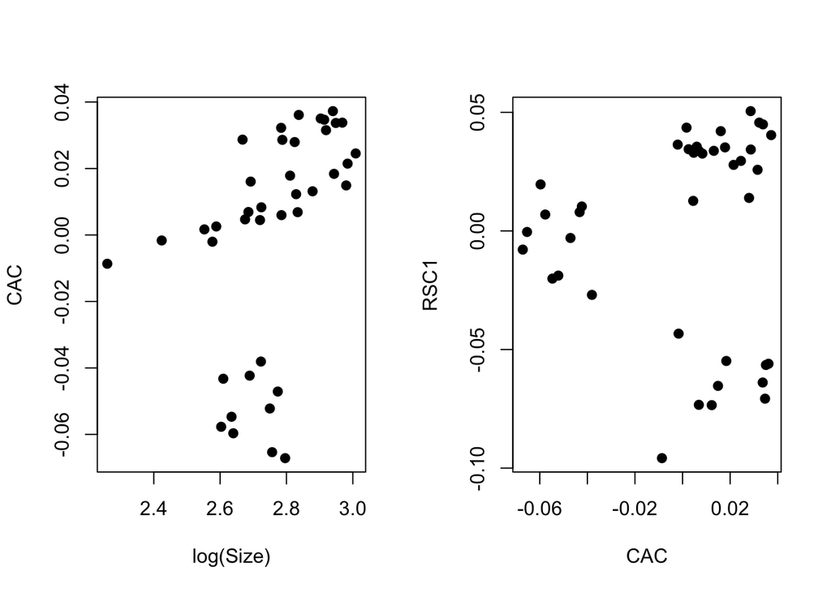

```r
# CAC (should not change from last time; model change has no effect)
plotAllometry(fit.unique, size = gdf$Csize, logsz = TRUE, method = "CAC", pch = 19)
```

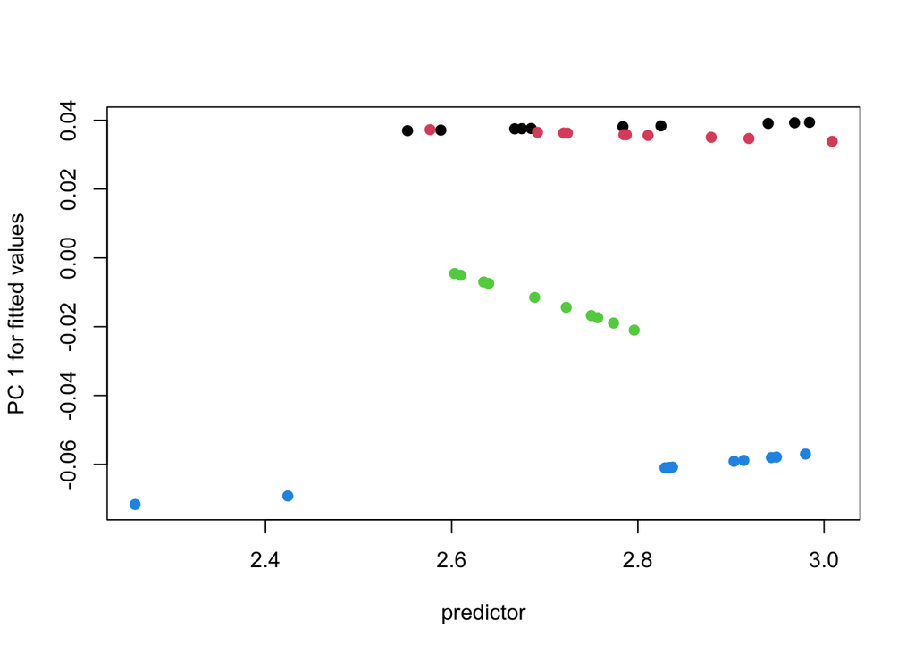

```r
# Predline
plotAllometry(fit.unique, size = gdf$Csize, logsz = TRUE, method = "PredLine",
pch = 19, col = as.numeric(interaction(gdf$species, gdf$site)))
```

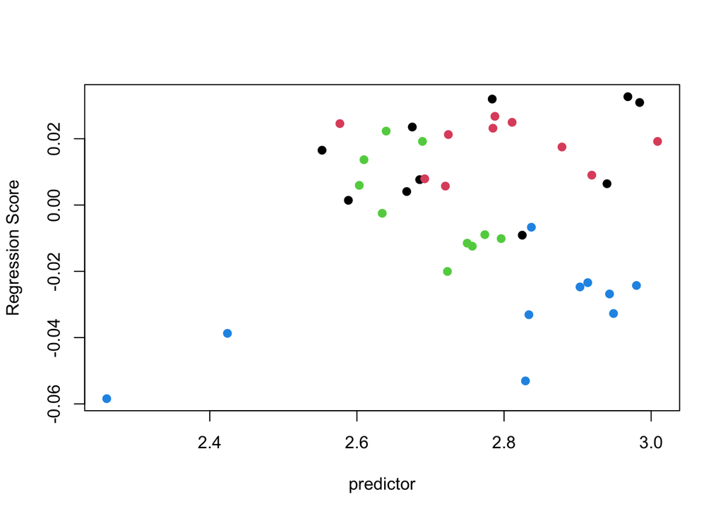

```r
# RegScore
plotAllometry(fit.unique, size = gdf$Csize, logsz = TRUE, method = "RegScore",
pch = 19, col = as.numeric(interaction(gdf$species, gdf$site)))
```

## **3: Size-Shape PCA**

One can also generate a plot of size-shape space (sensu Mitteroecker et al. 2004):

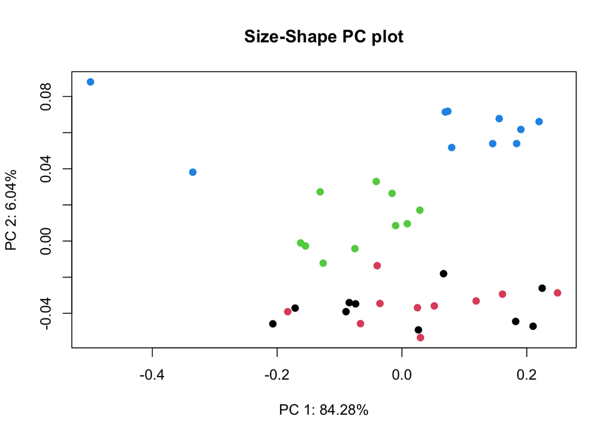

```r
pc.plot <- plotAllometry(fit.unique, size = gdf$Csize, logsz = TRUE, method = "size.shape",
pch = 19, col = as.numeric(interaction(gdf$species, gdf$site)))
```

```r
summary(pc.plot$size.shape.PCA)
```

```
## Importance of components:
##                           PC1     PC2     PC3     PC4     PC5     PC6     PC7
## Standard deviation     0.1607 0.04302 0.03771 0.01985 0.01492 0.01314 0.01291
## Proportion of Variance 0.8428 0.06044 0.04643 0.01287 0.00727 0.00563 0.00544
## Cumulative Proportion  0.8428 0.90328 0.94971 0.96258 0.96985 0.97548 0.98093
##                            PC8      PC9    PC10     PC11     PC12     PC13
## Standard deviation     0.01217 0.009205 0.00901 0.008189 0.007239 0.006479
## Proportion of Variance 0.00483 0.002770 0.00265 0.002190 0.001710 0.001370
## Cumulative Proportion  0.98576 0.988530 0.99118 0.993370 0.995080 0.996450
##                            PC14     PC15     PC16     PC17     PC18     PC19
## Standard deviation     0.005112 0.004286 0.004155 0.003962 0.003686 0.003026
## Proportion of Variance 0.000850 0.000600 0.000560 0.000510 0.000440 0.000300
## Cumulative Proportion  0.997300 0.997900 0.998470 0.998980 0.999420 0.999720
##                            PC20     PC21      PC22      PC23      PC24
## Standard deviation     0.002242 0.001862 1.332e-15 2.909e-16 7.468e-17
## Proportion of Variance 0.000160 0.000110 0.000e+00 0.000e+00 0.000e+00
## Cumulative Proportion  0.999890 1.000000 1.000e+00 1.000e+00 1.000e+00
##                             PC25
## Standard deviation     1.191e-17
## Proportion of Variance 0.000e+00
## Cumulative Proportion  1.000e+00
```